# GSEM factor analysis - datadriven

AA & JP

12 July, 2024

## Standard factor models

Here, I test standard latent factor models that are suggested by exploratory factor analysis (data-driven). Instead of using half the chromosomes for EFA and the other half for CFA, I just used the full genome for both. For some of the traits the signal is quite localized, so that even and odd chromosomes are unlikely to share signal. Instead of focusing on absolute fit, we will compare models and focus on relative fit.

We use promax rotation everywhere, free all first indicator loadings, and restrain all factor variance to 1. I allow for cross loadings. The minimum factor loading is set to 0.3 throughout. Where necessary, variance is forced to be >0.

### 1 factor

EFA:

```r
load('data/mldsc_29May2023.14.TOT.RData')

Ssmooth <- as.matrix((nearPD(ldscOut$S, corr = FALSE))$mat)

EFA <-factanal(covmat = Ssmooth, factors = 1, rotation = 'promax')
```

```r
print(EFA, digits = 2, cutoff = .3, sort = TRUE)
```

```
##
## Call:
## factanal(factors = 1, covmat = Ssmooth, rotation = "promax")
##
## Uniquenesses:
##  SMKINI  SMKCES  PACKYE  SMKAGE  SMKDEP  ALCCON  ALCFRQ    ALCP  ALCDEP   CANEV
##    0.43    0.70    0.60    0.54    0.63    0.61    1.00    0.74    0.28    0.80
##  CANDEP   CANFL  COCDEP OPIODEP
##    0.49    0.75    0.36    0.38
##
## Loadings:
##         Factor1
## SMKINI   0.76
## SMKCES   0.55
## PACKYE   0.63
## SMKAGE  -0.68
## SMKDEP   0.61
## ALCCON   0.63
## ALCP     0.51
## ALCDEP   0.85
## CANDEP   0.71
## COCDEP   0.80
## OPIODEP  0.79
## ALCFRQ
## CANEV    0.45
## CANFL    0.50
##
##                Factor1
## SS loadings       5.70
## Proportion Var    0.41
##
## The degrees of freedom for the model is 77 and the fit was 35.0354
```

CFA: Model fit is mediocre. Note that alcohol frequency didn’t load on the latent factor and is excluded.

```r
load('data/mldsc_29May2023.14.TOT.RData')

CFA <- 'G =~ NA*SMKINI + SMKCES + PACKYE + SMKAGE + SMKDEP + ALCDEP + CANDEP + COCDEP + OPIODEP + ALCCON + CANEV + CANFL + ALCP

G~~1*G
'

#run the model
fit <- usermodel(ldscOut, estimation = "DWLS", model = CFA, CFIcalc = TRUE)
```

```r
fitlabel <- paste0("CFI = ", round(fit$modelfit$CFI,3), ", SRMR = ", round(fit$modelfit$SRMR,3))
kable(fitlabel)
```

| x |
| --- |
| CFI = 0.793, SRMR = 0.154 |

**Click to expand table with model parameters**

```r
kable(fit$results)
```

|  | lhs | op | rhs | Unstand_Est | Unstand_SE | STD_Genotype | STD_Genotype_SE | STD_All | p_value |
| --- | --- | --- | --- | --- | --- | --- | --- | --- | --- |
| 21 | G | =~ | SMKINI | 0.2784738 | 0.0080216147461121 | 0.8074290 | 0.0232585336480991 | 0.8074290 | 0.0000000 |
| 19 | G | =~ | SMKCES | 0.1390936 | 0.00778785222200984 | 0.5176713 | 0.02898440237746 | 0.5176713 | 0.0000000 |
| 17 | G | =~ | PACKYE | 0.1829408 | 0.00953750295019529 | 0.6059981 | 0.0315932873156245 | 0.6059977 | 0.0000000 |
| 18 | G | =~ | SMKAGE | -0.1414873 | 0.00594679305988721 | -0.6490023 | 0.0272779522740566 | -0.6490024 | 0.0000000 |
| 20 | G | =~ | SMKDEP | 0.2158781 | 0.0160494492460182 | 0.6134419 | 0.0456062466893192 | 0.6134427 | 0.0000000 |
| 10 | G | =~ | ALCDEP | 0.3381765 | 0.0177340892231324 | 0.8888452 | 0.0466113029045866 | 0.8888444 | 0.0000000 |
| 12 | G | =~ | CANDEP | 0.2060727 | 0.0209283578388797 | 0.6888303 | 0.0699564914112479 | 0.6888314 | 0.0000000 |
| 15 | G | =~ | COCDEP | 0.3892263 | 0.0308076411374582 | 0.7138820 | 0.0565042529404368 | 0.7138806 | 0.0000000 |
| 16 | G | =~ | OPIODEP | 0.3364400 | 0.0375362849808652 | 0.7532847 | 0.0840431011731916 | 0.7532839 | 0.0000000 |
| 9 | G | =~ | ALCCON | 0.1590653 | 0.00634996308206926 | 0.6048677 | 0.0241466187433038 | 0.6048679 | 0.0000000 |
| 13 | G | =~ | CANEV | 0.2429141 | 0.0174356360881744 | 0.4231974 | 0.0303758927478725 | 0.4231973 | 0.0000000 |
| 14 | G | =~ | CANFL | 0.1155054 | 0.0164806785936354 | 0.5452628 | 0.0778000708795312 | 0.5452646 | 0.0000000 |
| 11 | G | =~ | ALCP | 0.1259696 | 0.0075278071951093 | 0.5231404 | 0.0312623079865364 | 0.5231404 | 0.0000000 |
| 27 | SMKINI | ~~ | SMKINI | 0.0414008 | 0.00319576211557879 | 0.3480584 | 0.0268667455986745 | 0.3480584 | 0.0000000 |
| 25 | SMKCES | ~~ | SMKCES | 0.0528479 | 0.00322197314003444 | 0.7320165 | 0.0446287876603464 | 0.7320164 | 0.0000000 |
| 23 | PACKYE | ~~ | PACKYE | 0.0576665 | 0.00528564346168626 | 0.6327676 | 0.0579986653607602 | 0.6327668 | 0.0000000 |
| 24 | SMKAGE | ~~ | SMKAGE | 0.0275085 | 0.00215036493358445 | 0.5787958 | 0.0452449216921968 | 0.5787959 | 0.0000000 |
| 26 | SMKDEP | ~~ | SMKDEP | 0.0772398 | 0.0171204973260477 | 0.6236865 | 0.138243453361873 | 0.6236881 | 0.0000064 |
| 1 | ALCCON | ~~ | ALCCON | 0.0438542 | 0.00329993833687621 | 0.6341346 | 0.047717306384957 | 0.6341349 | 0.0000000 |
| 3 | ALCP | ~~ | ALCP | 0.0421139 | 0.00374300478285194 | 0.7263242 | 0.064554332250544 | 0.7263241 | 0.0000000 |
| 2 | ALCDEP | ~~ | ALCDEP | 0.0303931 | 0.0249349172261634 | 0.2099561 | 0.172255238035503 | 0.2099557 | 0.2228828 |
| 5 | CANEV | ~~ | CANEV | 0.2704631 | 0.0185101622114617 | 0.8209045 | 0.0561814200554732 | 0.8209041 | 0.0000000 |
| 4 | CANDEP | ~~ | CANDEP | 0.0470323 | 0.0283350895633477 | 0.5255096 | 0.316599469006713 | 0.5255112 | 0.0969422 |
| 6 | CANFL | ~~ | CANFL | 0.0315320 | 0.0156330804956141 | 0.7026819 | 0.348380797501642 | 0.7026865 | 0.0436950 |
| 7 | COCDEP | ~~ | COCDEP | 0.1457795 | 0.0508539468671215 | 0.4903765 | 0.171068438035964 | 0.4903745 | 0.0041487 |
| 22 | OPIODEP | ~~ | OPIODEP | 0.0862971 | 0.069151542369835 | 0.4325642 | 0.346659441829764 | 0.4325633 | 0.2120523 |
| 8 | G | ~~ | G | 1.0000000 |  | 1.0000000 |  | 1.0000000 | NA |

### 2 factors

EFA:

```r
load('data/mldsc_29May2023.14.TOT.RData')

Ssmooth <- as.matrix((nearPD(ldscOut$S, corr = FALSE))$mat)

EFA <-factanal(covmat = Ssmooth, factors = 2, rotation = 'promax')
```

```r
print(EFA, digits = 2, cutoff = .3, sort = TRUE)
```

```
##
## Call:
## factanal(factors = 2, covmat = Ssmooth, rotation = "promax")
##
## Uniquenesses:
##  SMKINI  SMKCES  PACKYE  SMKAGE  SMKDEP  ALCCON  ALCFRQ    ALCP  ALCDEP   CANEV
##    0.36    0.46    0.34    0.52    0.46    0.65    0.79    0.71    0.33    0.00
##  CANDEP   CANFL  COCDEP OPIODEP
##    0.51    0.24    0.36    0.37
##
## Loadings:
##         Factor1 Factor2
## SMKINI   0.52    0.43
## SMKCES   0.82   -0.33
## PACKYE   0.90
## SMKAGE  -0.70
## SMKDEP   0.80
## ALCDEP   0.75
## CANDEP   0.57
## COCDEP   0.77
## OPIODEP  0.58    0.34
## CANEV            1.06
## CANFL            0.88
## ALCCON   0.43
## ALCFRQ  -0.37    0.47
## ALCP             0.39
##
##                Factor1 Factor2
## SS loadings       5.10    2.95
## Proportion Var    0.36    0.21
## Cumulative Var    0.36    0.58
##
## Factor Correlations:
##         Factor1 Factor2
## Factor1    1.00    0.43
## Factor2    0.43    1.00
##
## The degrees of freedom for the model is 64 and the fit was 32.5361
```

CFA: Model fit is poor and the solution doesn’t make much sense.

```r
load('data/mldsc_29May2023.14.TOT.RData')

CFA <- '
F1 =~ NA*SMKINI + SMKCES + PACKYE + SMKAGE + SMKDEP + ALCDEP + CANDEP + COCDEP + OPIODEP + ALCCON + ALCFRQ
F2 =~ NA*SMKINI + SMKCES + OPIODEP + CANEV + CANFL + ALCFRQ + ALCP

F1~~1*F1
F2~~1*F2

'

#run the model
fit <- usermodel(ldscOut, estimation = "DWLS", model = CFA, CFIcalc = TRUE)
```

```r
fitlabel <- paste0("CFI = ", round(fit$modelfit$CFI,3), ", SRMR = ", round(fit$modelfit$SRMR,3))
kable(fitlabel)
```

| x |
| --- |
| CFI = 0.622, SRMR = 0.147 |

**Click to expand table with model parameters**

```r
kable(fit$results)
```

|  | lhs | op | rhs | Unstand_Est | Unstand_SE | STD_Genotype | STD_Genotype_SE | STD_All | p_value |
| --- | --- | --- | --- | --- | --- | --- | --- | --- | --- |
| 21 | F1 | =~ | SMKINI | 0.2097340 | 0.00773535822827966 | 0.6081925 | 0.0224312680903696 | 0.6081928 | 0.0000000 |
| 19 | F1 | =~ | SMKCES | 0.2087557 | 0.00930365860376346 | 0.7768756 | 0.0346232419806176 | 0.7768752 | 0.0000000 |
| 17 | F1 | =~ | PACKYE | 0.2038204 | 0.00955527692991299 | 0.6754964 | 0.031667852494629 | 0.6754960 | 0.0000000 |
| 18 | F1 | =~ | SMKAGE | -0.1488099 | 0.00609644566271355 | -0.6804393 | 0.0278762700829483 | -0.6804390 | 0.0000000 |
| 20 | F1 | =~ | SMKDEP | 0.2291874 | 0.016231411463727 | 0.6512080 | 0.0461195776193641 | 0.6512078 | 0.0000000 |
| 12 | F1 | =~ | ALCDEP | 0.3339379 | 0.0176301042157469 | 0.8776362 | 0.0463344723115518 | 0.8776319 | 0.0000000 |
| 14 | F1 | =~ | CANDEP | 0.2076115 | 0.0207439715551002 | 0.6933299 | 0.0692755507791822 | 0.6933322 | 0.0000000 |
| 15 | F1 | =~ | COCDEP | 0.4019437 | 0.0306508260823132 | 0.7367851 | 0.0561848461512308 | 0.7367845 | 0.0000000 |
| 16 | F1 | =~ | OPIODEP | 0.2796200 | 0.046878084067793 | 0.6257458 | 0.104906071538493 | 0.6257403 | 0.0000000 |
| 11 | F1 | =~ | ALCCON | 0.1456817 | 0.00634713789480249 | 0.5540030 | 0.0241370751437879 | 0.5540029 | 0.0000000 |
| 13 | F1 | =~ | ALCFRQ | -0.1533670 | 0.014686842684239 | -0.5330383 | 0.0510453430557436 | -0.5330378 | 0.0000000 |
| 29 | F2 | =~ | SMKINI | 0.1132137 | 0.00926741628455535 | 0.3283001 | 0.0268739770408218 | 0.3283002 | 0.0000000 |
| 28 | F2 | =~ | SMKCES | -0.0842960 | 0.01061685546952 | -0.3137045 | 0.0395102355032176 | -0.3137043 | 0.0000000 |
| 27 | F2 | =~ | OPIODEP | 0.0908673 | 0.0446321904234251 | 0.2033454 | 0.0998801322227733 | 0.2033436 | 0.0417590 |
| 25 | F2 | =~ | CANEV | 0.4171388 | 0.0233784455592393 | 0.7267531 | 0.0407308270602971 | 0.7267541 | 0.0000000 |
| 26 | F2 | =~ | CANFL | 0.1560593 | 0.0199080472042108 | 0.7362280 | 0.0939186168638707 | 0.7362231 | 0.0000000 |
| 23 | F2 | =~ | ALCFRQ | 0.2215156 | 0.0161479545351987 | 0.7698918 | 0.0561234747880799 | 0.7698911 | 0.0000000 |
| 24 | F2 | =~ | ALCP | 0.1822535 | 0.00899582444855143 | 0.7577183 | 0.0374001243480265 | 0.7577181 | 0.0000000 |
| 35 | SMKINI | ~~ | SMKINI | 0.0386121 | 0.00330974426301992 | 0.3246885 | 0.0278316875441143 | 0.3246888 | 0.0000000 |
| 33 | SMKCES | ~~ | SMKCES | 0.0389389 | 0.00327491804324977 | 0.5392766 | 0.0453551064034507 | 0.5392760 | 0.0000000 |
| 31 | PACKYE | ~~ | PACKYE | 0.0495008 | 0.00521333300013981 | 0.5437057 | 0.0572619522460053 | 0.5437051 | 0.0000000 |
| 32 | SMKAGE | ~~ | SMKAGE | 0.0256838 | 0.00209807992974615 | 0.5370034 | 0.0438670092392502 | 0.5370028 | 0.0000000 |
| 34 | SMKDEP | ~~ | SMKDEP | 0.0713360 | 0.0169024103843362 | 0.5759287 | 0.136460462004916 | 0.5759284 | 0.0000244 |
| 1 | ALCCON | ~~ | ALCCON | 0.0479260 | 0.00344042749924711 | 0.6930812 | 0.0497537401754798 | 0.6930808 | 0.0000000 |
| 3 | ALCFRQ | ~~ | ALCFRQ | 0.0438211 | 0.00430736763820257 | 0.5293315 | 0.0520308601425348 | 0.5293306 | 0.0000000 |
| 4 | ALCP | ~~ | ALCP | 0.0246381 | 0.00383878295481699 | 0.4258636 | 0.066352528919323 | 0.4258633 | 0.0000000 |
| 2 | ALCDEP | ~~ | ALCDEP | 0.0332633 | 0.0248534499549801 | 0.2297645 | 0.171666378389243 | 0.2297622 | 0.1807733 |
| 6 | CANEV | ~~ | CANEV | 0.1554405 | 0.0186434694791616 | 0.4718273 | 0.0565902689648786 | 0.4718285 | 0.0000000 |
| 5 | CANDEP | ~~ | CANDEP | 0.0465621 | 0.0283389514663674 | 0.5192869 | 0.316052882108185 | 0.5192904 | 0.1003740 |
| 7 | CANFL | ~~ | CANFL | 0.0205771 | 0.0155824816939563 | 0.4579816 | 0.346803037037326 | 0.4579755 | 0.1866589 |
| 8 | COCDEP | ~~ | COCDEP | 0.1360497 | 0.0505959920334456 | 0.4571494 | 0.170008270582498 | 0.4571486 | 0.0071679 |
| 30 | OPIODEP | ~~ | OPIODEP | 0.0880890 | 0.0691503181624841 | 0.4411667 | 0.346301299307091 | 0.4411590 | 0.2027072 |
| 10 | F1 | ~~ | F2 | 0.4948934 | 0.0336264633478455 | 0.4948964 | 0.0336265108053945 | 0.4948964 | 0.0000000 |
| 9 | F1 | ~~ | F1 | 1.0000000 |  | 1.0000000 |  | 1.0000000 | NA |
| 22 | F2 | ~~ | F2 | 1.0000000 |  | 1.0000000 |  | 1.0000000 | NA |

### 3 factors

EFA:

```r
load('data/mldsc_29May2023.14.TOT.RData')

Ssmooth <- as.matrix((nearPD(ldscOut$S, corr = FALSE))$mat)

EFA <-factanal(covmat = Ssmooth, factors = 3, rotation = 'promax')
```

```r
print(EFA, digits = 2, cutoff = .3, sort = TRUE)
```

```
##
## Call:
## factanal(factors = 3, covmat = Ssmooth, rotation = "promax")
##
## Uniquenesses:
##  SMKINI  SMKCES  PACKYE  SMKAGE  SMKDEP  ALCCON  ALCFRQ    ALCP  ALCDEP   CANEV
##    0.37    0.46    0.30    0.50    0.47    0.08    0.24    0.32    0.23    0.00
##  CANDEP   CANFL  COCDEP OPIODEP
##    0.51    0.23    0.35    0.38
##
## Loadings:
##         Factor1 Factor2 Factor3
## SMKCES   0.80   -0.32
## PACKYE   0.91
## SMKAGE  -0.70
## SMKDEP   0.77
## ALCDEP   0.69            0.40
## CANDEP   0.54
## COCDEP   0.76
## OPIODEP  0.54    0.40
## CANEV            1.07
## CANFL            0.91
## ALCCON   0.33            0.90
## ALCFRQ  -0.51            0.80
## ALCP                     0.74
## SMKINI   0.47    0.45
##
##                Factor1 Factor2 Factor3
## SS loadings       4.85    2.62    2.17
## Proportion Var    0.35    0.19    0.16
## Cumulative Var    0.35    0.53    0.69
##
## Factor Correlations:
##         Factor1 Factor2 Factor3
## Factor1    1.00    0.42    0.47
## Factor2    0.42    1.00    0.22
## Factor3    0.47    0.22    1.00
##
## The degrees of freedom for the model is 52 and the fit was 30.6153
```

CFA: Model fit approaches the cut-offs, but the factor structure is not super clear.

```r
load('data/mldsc_29May2023.14.TOT.RData')

CFA <- '
F1 =~ NA*SMKCES + PACKYE + SMKAGE + SMKDEP + ALCDEP + CANDEP + COCDEP + OPIODEP + ALCCON + ALCFRQ + SMKINI
F2 =~ NA*SMKCES + OPIODEP + CANEV + CANFL + SMKINI
F3 =~ NA*ALCDEP + ALCCON + ALCFRQ + ALCP

F1~~1*F1
F2~~1*F2
F3~~1*F3

'

#run the model
fit <- usermodel(ldscOut, estimation = "DWLS", model = CFA, CFIcalc = TRUE)
```

```r
fitlabel <- paste0("CFI = ", round(fit$modelfit$CFI,3), ", SRMR = ", round(fit$modelfit$SRMR,3))
kable(fitlabel)
```

| x |
| --- |
| CFI = 0.936, SRMR = 0.105 |

**Click to expand table with model parameters**

```r
kable(fit$results)
```

|  | lhs | op | rhs | Unstand_Est | Unstand_SE | STD_Genotype | STD_Genotype_SE | STD_All | p_value |
| --- | --- | --- | --- | --- | --- | --- | --- | --- | --- |
| 20 | F1 | =~ | SMKCES | 0.1854541 | 0.00724728092616348 | 0.6901590 | 0.0269704415044337 | 0.6901590 | 0.0000000 |
| 18 | F1 | =~ | PACKYE | 0.2342865 | 0.00969652371940295 | 0.7764661 | 0.0321359654964025 | 0.7764663 | 0.0000000 |
| 19 | F1 | =~ | SMKAGE | -0.1539430 | 0.0065183832023781 | -0.7039115 | 0.0298055998087046 | -0.7039114 | 0.0000000 |
| 21 | F1 | =~ | SMKDEP | 0.2515093 | 0.0170124393817812 | 0.7146326 | 0.0483387703582918 | 0.7146314 | 0.0000000 |
| 13 | F1 | =~ | ALCDEP | 0.2338790 | 0.0211296131115621 | 0.6146673 | 0.0555317158426929 | 0.6146673 | 0.0000000 |
| 15 | F1 | =~ | CANDEP | 0.2073614 | 0.0211454309687219 | 0.6924938 | 0.0706162304205312 | 0.6924938 | 0.0000000 |
| 16 | F1 | =~ | COCDEP | 0.4129889 | 0.0308440612702791 | 0.7570339 | 0.056539055628839 | 0.7570342 | 0.0000000 |
| 17 | F1 | =~ | OPIODEP | 0.2619594 | 0.0407062616525075 | 0.5862239 | 0.0910943066241813 | 0.5862239 | 0.0000000 |
| 12 | F1 | =~ | ALCCON | 0.0295683 | 0.00950716613323269 | 0.1124421 | 0.0361541674827097 | 0.1124421 | 0.0018702 |
| 14 | F1 | =~ | ALCFRQ | -0.1983355 | 0.0146373250930993 | -0.6893260 | 0.0508728745195003 | -0.6893260 | 0.0000000 |
| 22 | F1 | =~ | SMKINI | 0.2030940 | 0.00762318359080895 | 0.5889380 | 0.0221059163485791 | 0.5889381 | 0.0000000 |
| 28 | F2 | =~ | SMKCES | -0.0311884 | 0.00901659499850727 | -0.1160666 | 0.033554860808981 | -0.1160666 | 0.0005422 |
| 27 | F2 | =~ | OPIODEP | 0.1727066 | 0.0366308614681117 | 0.3864907 | 0.0819742003417337 | 0.3864907 | 0.0000024 |
| 25 | F2 | =~ | CANEV | 0.5335957 | 0.0266190985569128 | 0.9296528 | 0.0463768965798438 | 0.9296527 | 0.0000000 |
| 26 | F2 | =~ | CANFL | 0.1807195 | 0.0203096295475839 | 0.8525663 | 0.0958131466579723 | 0.8525658 | 0.0000000 |
| 29 | F2 | =~ | SMKINI | 0.1875507 | 0.00962882296519606 | 0.5438641 | 0.0279219247120459 | 0.5438642 | 0.0000000 |
| 32 | F3 | =~ | ALCDEP | 0.1809731 | 0.0221555716800392 | 0.4756229 | 0.0582280816302054 | 0.4756229 | 0.0000000 |
| 31 | F3 | =~ | ALCCON | 0.2157458 | 0.00864330670292245 | 0.8204438 | 0.0328690357263976 | 0.8204439 | 0.0000000 |
| 33 | F3 | =~ | ALCFRQ | 0.2705340 | 0.0134509928567196 | 0.9402548 | 0.0467497028732268 | 0.9402548 | 0.0000000 |
| 34 | F3 | =~ | ALCP | 0.1982659 | 0.0083008465363281 | 0.8242888 | 0.0345107316448057 | 0.8242885 | 0.0000000 |
| 40 | SMKINI | ~~ | SMKINI | 0.0325635 | 0.00359910628603609 | 0.2738276 | 0.0302648829816598 | 0.2738276 | 0.0000000 |
| 38 | SMKCES | ~~ | SMKCES | 0.0383487 | 0.0032775552228212 | 0.5311007 | 0.0453916290692864 | 0.5311006 | 0.0000000 |
| 36 | PACKYE | ~~ | PACKYE | 0.0361535 | 0.00518504456802135 | 0.3970998 | 0.05695123039059 | 0.3971000 | 0.0000000 |
| 37 | SMKAGE | ~~ | SMKAGE | 0.0241297 | 0.0020904407840386 | 0.5045088 | 0.0437072909331898 | 0.5045087 | 0.0000000 |
| 39 | SMKDEP | ~~ | SMKDEP | 0.0606060 | 0.0166705632956822 | 0.4893036 | 0.134588644688185 | 0.4893019 | 0.0002774 |
| 1 | ALCCON | ~~ | ALCCON | 0.0168612 | 0.00251664387184154 | 0.2438383 | 0.0363944483541839 | 0.2438383 | 0.0000000 |
| 3 | ALCFRQ | ~~ | ALCFRQ | 0.0112006 | 0.00411918700359035 | 0.1352949 | 0.0497575113814898 | 0.1352949 | 0.0065453 |
| 4 | ALCP | ~~ | ALCP | 0.0185450 | 0.00333380332219809 | 0.3205486 | 0.0576240217755452 | 0.3205484 | 0.0000000 |
| 2 | ALCDEP | ~~ | ALCDEP | 0.0250318 | 0.0253751738313635 | 0.1728987 | 0.175269997767316 | 0.1728987 | 0.3239043 |
| 6 | CANEV | ~~ | CANEV | 0.0447215 | 0.0247378773187573 | 0.1357460 | 0.0750895073633289 | 0.1357459 | 0.0706351 |
| 5 | CANDEP | ~~ | CANDEP | 0.0466664 | 0.0284534003150796 | 0.5204523 | 0.317329304553986 | 0.5204523 | 0.1009845 |
| 7 | CANFL | ~~ | CANFL | 0.0122722 | 0.0158041634418188 | 0.2731319 | 0.351736770328476 | 0.2731316 | 0.4374436 |
| 8 | COCDEP | ~~ | COCDEP | 0.1270494 | 0.0504163086377878 | 0.4268990 | 0.169404526452188 | 0.4268993 | 0.0117353 |
| 35 | OPIODEP | ~~ | OPIODEP | 0.0894330 | 0.0690919729983951 | 0.4478761 | 0.346009101024539 | 0.4478761 | 0.1955255 |
| 10 | F1 | ~~ | F2 | 0.1304011 | 0.0392784681697259 | 0.1304019 | 0.0392784561234571 | 0.1304019 | 0.0009005 |
| 11 | F1 | ~~ | F3 | 0.3815076 | 0.0413590646887258 | 0.3815092 | 0.0413590965519362 | 0.3815092 | 0.0000000 |
| 24 | F2 | ~~ | F3 | 0.5084882 | 0.0273151474240049 | 0.5084886 | 0.0273151717521615 | 0.5084886 | 0.0000000 |
| 9 | F1 | ~~ | F1 | 1.0000000 |  | 1.0000000 |  | 1.0000000 | NA |
| 23 | F2 | ~~ | F2 | 1.0000000 |  | 1.0000000 |  | 1.0000000 | NA |
| 30 | F3 | ~~ | F3 | 1.0000000 |  | 1.0000000 |  | 1.0000000 | NA |

### 4 factors

EFA:

```r
load('data/mldsc_29May2023.14.TOT.RData')

Ssmooth <- as.matrix((nearPD(ldscOut$S, corr = FALSE))$mat)

EFA <-factanal(covmat = Ssmooth, factors = 4, rotation = 'promax')
print(EFA, digits = 2, cutoff = .3, sort = TRUE)
```

```
##
## Call:
## factanal(factors = 4, covmat = Ssmooth, rotation = "promax")
##
## Uniquenesses:
##  SMKINI  SMKCES  PACKYE  SMKAGE  SMKDEP  ALCCON  ALCFRQ    ALCP  ALCDEP   CANEV
##    0.45    0.40    0.18    0.51    0.43    0.12    0.22    0.29    0.25    0.15
##  CANDEP   CANFL  COCDEP OPIODEP
##    0.29    0.00    0.25    0.00
##
## Loadings:
##         Factor1 Factor2 Factor3 Factor4
## SMKCES   0.87
## PACKYE   0.98
## SMKDEP   0.72
## ALCDEP   0.59            0.42
## CANDEP           0.67
## COCDEP   0.31    0.70
## OPIODEP          1.17
## ALCCON                   0.87
## ALCFRQ  -0.58            0.84
## ALCP                     0.85
## CANEV   -0.32                    0.81
## CANFL                            1.14
## SMKINI   0.33                    0.36
## SMKAGE  -0.33   -0.47
##
##                Factor1 Factor2 Factor3 Factor4
## SS loadings       3.43    2.68    2.42    2.23
## Proportion Var    0.25    0.19    0.17    0.16
## Cumulative Var    0.25    0.44    0.61    0.77
##
## Factor Correlations:
##         Factor1 Factor2 Factor3 Factor4
## Factor1    1.00    0.59    0.49   -0.25
## Factor2    0.59    1.00    0.38   -0.65
## Factor3    0.49    0.38    1.00   -0.24
## Factor4   -0.25   -0.65   -0.24    1.00
##
## The degrees of freedom for the model is 41 and the fit was 29.4337
```

CFA: Model fit is good, though first factor is still messy.

```r
load('data/mldsc_29May2023.14.TOT.RData')

CFA <- '
F1 =~ NA*SMKCES + PACKYE + SMKDEP + ALCDEP + ALCFRQ + COCDEP + CANEV + SMKINI + SMKAGE
F2 =~ NA*CANDEP + COCDEP + OPIODEP + SMKAGE
F3 =~ NA*ALCDEP + ALCCON + ALCFRQ + ALCP
F4 =~ NA*CANEV + CANFL + SMKINI

F1~~1*F1
F2~~1*F2
F3~~1*F3
F4~~1*F4

'

#run the model
fit <- usermodel(ldscOut, estimation = "DWLS", model = CFA, CFIcalc = TRUE)
```

```r
fitlabel <- paste0("CFI = ", round(fit$modelfit$CFI,3), ", SRMR = ", round(fit$modelfit$SRMR,3))
kable(fitlabel)
```

| x |
| --- |
| CFI = 0.953, SRMR = 0.066 |

**Click to expand table with model parameters**

```r
kable(fit$results)
```

|  | lhs | op | rhs | Unstand_Est | Unstand_SE | STD_Genotype | STD_Genotype_SE | STD_All | p_value |
| --- | --- | --- | --- | --- | --- | --- | --- | --- | --- |
| 19 | F1 | =~ | SMKCES | 0.1899700 | 0.00786400199181626 | 0.7069652 | 0.0292655477337792 | 0.7069652 | 0.0000000 |
| 17 | F1 | =~ | PACKYE | 0.2625313 | 0.0101378295487566 | 0.8700752 | 0.0335985455257684 | 0.8700752 | 0.0000000 |
| 20 | F1 | =~ | SMKDEP | 0.2700338 | 0.0176781289658409 | 0.7672686 | 0.0502302670625142 | 0.7672692 | 0.0000000 |
| 13 | F1 | =~ | ALCDEP | 0.2076111 | 0.0211964260738504 | 0.5456320 | 0.0557072895090233 | 0.5456305 | 0.0000000 |
| 14 | F1 | =~ | ALCFRQ | -0.2025342 | 0.00998187651413266 | -0.7039156 | 0.0346923853832763 | -0.7039155 | 0.0000000 |
| 16 | F1 | =~ | COCDEP | 0.2138638 | 0.048969135908532 | 0.3920269 | 0.0897633195451795 | 0.3920269 | 0.0000126 |
| 15 | F1 | =~ | CANEV | -0.1136911 | 0.052991423087046 | -0.1980775 | 0.0923238371442073 | -0.1980775 | 0.0319159 |
| 21 | F1 | =~ | SMKINI | 0.1578830 | 0.0226812441205588 | 0.4578328 | 0.0657717734557814 | 0.4578328 | 0.0000000 |
| 18 | F1 | =~ | SMKAGE | -0.0724884 | 0.0151015210106419 | -0.3314557 | 0.0690524491607782 | -0.3314557 | 0.0000016 |
| 25 | F2 | =~ | CANDEP | 0.2388035 | 0.0238151901572678 | 0.7974957 | 0.0795319637390985 | 0.7974940 | 0.0000000 |
| 26 | F2 | =~ | COCDEP | 0.2517174 | 0.052933724573892 | 0.4614110 | 0.0970306091998501 | 0.4614110 | 0.0000020 |
| 27 | F2 | =~ | OPIODEP | 0.3934321 | 0.0453608023748563 | 0.8804386 | 0.101510343551388 | 0.8804348 | 0.0000000 |
| 28 | F2 | =~ | SMKAGE | -0.1063077 | 0.0128156972524255 | -0.4860971 | 0.058600387058911 | -0.4860970 | 0.0000000 |
| 32 | F3 | =~ | ALCDEP | 0.2277978 | 0.0227649637288711 | 0.5986853 | 0.0598296227402828 | 0.5986837 | 0.0000000 |
| 31 | F3 | =~ | ALCCON | 0.2452025 | 0.00756661380680426 | 0.9324637 | 0.0287745395962368 | 0.9324640 | 0.0000000 |
| 33 | F3 | =~ | ALCFRQ | 0.2370749 | 0.0111632314104016 | 0.8239631 | 0.0387982314287072 | 0.8239629 | 0.0000000 |
| 34 | F3 | =~ | ALCP | 0.1980872 | 0.00845208349930893 | 0.8235470 | 0.0351395064465524 | 0.8235470 | 0.0000000 |
| 36 | F4 | =~ | CANEV | 0.5297649 | 0.0279145579278536 | 0.9229778 | 0.0486338845472173 | 0.9229777 | 0.0000000 |
| 37 | F4 | =~ | CANFL | 0.1662346 | 0.0189746841024284 | 0.7842319 | 0.0895153782812771 | 0.7842299 | 0.0000000 |
| 38 | F4 | =~ | SMKINI | 0.2311949 | 0.0106026321952443 | 0.6704259 | 0.0307458238832739 | 0.6704259 | 0.0000000 |
| 44 | SMKINI | ~~ | SMKINI | 0.0307771 | 0.00381035464754151 | 0.2588061 | 0.0320412909923564 | 0.2588061 | 0.0000000 |
| 42 | SMKCES | ~~ | SMKCES | 0.0361176 | 0.00334622054276285 | 0.5002003 | 0.0463426079720231 | 0.5002003 | 0.0000000 |
| 40 | PACKYE | ~~ | PACKYE | 0.0221209 | 0.0053660503726798 | 0.2429691 | 0.0589393872165095 | 0.2429691 | 0.0000375 |
| 41 | SMKAGE | ~~ | SMKAGE | 0.0224710 | 0.00235391672254093 | 0.4698294 | 0.0492161125620699 | 0.4698293 | 0.0000000 |
| 43 | SMKDEP | ~~ | SMKDEP | 0.0509444 | 0.0166244479895409 | 0.4112973 | 0.134216343324924 | 0.4112980 | 0.0021809 |
| 1 | ALCCON | ~~ | ALCCON | 0.0090248 | 0.00276368025706345 | 0.1305107 | 0.0399670098222886 | 0.1305108 | 0.0010927 |
| 3 | ALCFRQ | ~~ | ALCFRQ | 0.0195665 | 0.0033443662103595 | 0.2363541 | 0.0403978561180906 | 0.2363540 | 0.0000000 |
| 4 | ALCP | ~~ | ALCP | 0.0186158 | 0.00352399787414888 | 0.3217704 | 0.0609115147279551 | 0.3217704 | 0.0000001 |
| 2 | ALCDEP | ~~ | ALCDEP | 0.0162897 | 0.0259862438432072 | 0.1125197 | 0.179490763041311 | 0.1125191 | 0.5307519 |
| 6 | CANEV | ~~ | CANEV | 0.0519814 | 0.0241776484748781 | 0.1577850 | 0.0733888713418266 | 0.1577850 | 0.0315568 |
| 5 | CANDEP | ~~ | CANDEP | 0.0326379 | 0.0292163658150519 | 0.3640048 | 0.325838299799337 | 0.3640033 | 0.2639476 |
| 7 | CANFL | ~~ | CANFL | 0.0172978 | 0.015570993471757 | 0.3849854 | 0.346547359680162 | 0.3849835 | 0.2666122 |
| 8 | COCDEP | ~~ | COCDEP | 0.1270258 | 0.0511847525816628 | 0.4268222 | 0.171986485213608 | 0.4268223 | 0.0130753 |
| 39 | OPIODEP | ~~ | OPIODEP | 0.0448938 | 0.0717210975485789 | 0.2248366 | 0.359175476176028 | 0.2248346 | 0.5313477 |
| 10 | F1 | ~~ | F2 | 0.5710580 | 0.0735937821922467 | 0.5710589 | 0.0735938113558522 | 0.5710589 | 0.0000000 |
| 11 | F1 | ~~ | F3 | 0.3541088 | 0.0323280926152042 | 0.3541084 | 0.0323280643462507 | 0.3541084 | 0.0000000 |
| 12 | F1 | ~~ | F4 | 0.1337576 | 0.0962318886806366 | 0.1337579 | 0.0962319106567506 | 0.1337579 | 0.1645439 |
| 23 | F2 | ~~ | F3 | 0.3703671 | 0.045627808166205 | 0.3703673 | 0.0456278351431157 | 0.3703673 | 0.0000000 |
| 24 | F2 | ~~ | F4 | 0.6858276 | 0.0664273885025176 | 0.6858295 | 0.0664275603708728 | 0.6858295 | 0.0000000 |
| 30 | F3 | ~~ | F4 | 0.5251460 | 0.034985783718102 | 0.5251461 | 0.0349857438455439 | 0.5251461 | 0.0000000 |
| 9 | F1 | ~~ | F1 | 1.0000000 |  | 1.0000000 |  | 1.0000000 | NA |
| 22 | F2 | ~~ | F2 | 1.0000000 |  | 1.0000000 |  | 1.0000000 | NA |
| 29 | F3 | ~~ | F3 | 1.0000000 |  | 1.0000000 |  | 1.0000000 | NA |
| 35 | F4 | ~~ | F4 | 1.0000000 |  | 1.0000000 |  | 1.0000000 | NA |

#### Plot

```r
semPlotModel_GSEM=function(gsem.object=GWISoutput , est.label="STD_All"){

       object=gsem.object$results
       object$free=0
       numb=1:length(which(object$op!="~~"))
       object$free[which(object$op!="~~")]=numb
       varNames <- lavaanNames(object, type = "ov")
       factNames <- lavaanNames(object, type = "lv")
       factNames <- factNames[!factNames %in% varNames]
       n <- length(varNames)
       k <- length(factNames)
       if (is.null(object$label))
         object$label <- rep("", nrow(object))
       semModel <- new("semPlotModel")
       object$est <- object[,est.label]
       object$se <- object[,"STD_Genotype_SE"]

       if (is.null(object$group))
         object$group <- ""
       semModel@Pars <- data.frame(label = object$label, lhs = ifelse(object$op ==
                                                                        "~" | object$op == "~1", object$rhs, object$lhs), edge = "--",
                                   rhs = ifelse(object$op == "~" | object$op == "~1", object$lhs,
                                                object$rhs), est = object$est, std = NA, group = object$group,
                                   fixed = object$free==0, par = object$free, stringsAsFactors = FALSE)
       semModel@Pars$edge[object$op == "~~"] <- "<->"
       semModel@Pars$edge[object$op == "~*~"] <- "<->"
       semModel@Pars$edge[object$op == "~"] <- "~>"
       semModel@Pars$edge[object$op == "=~"] <- "->"
       semModel@Pars$edge[object$op == "~1"] <- "int"
       semModel@Pars$edge[grepl("\\|", object$op)] <- "|"
       semModel@Thresholds <- semModel@Pars[grepl("\\|", semModel@Pars$edge),
                                            -(3:4)]
       semModel@Pars <- semModel@Pars[!object$op %in% c(":=", "<",
                                                        ">", "==", "|", "<", ">"), ]
       semModel@Vars <- data.frame(name = c(varNames, factNames),
                                   manifest = c(varNames, factNames) %in% varNames, exogenous = NA,
                                   stringsAsFactors = FALSE)
       semModel@ObsCovs <- list()
       semModel@ImpCovs <- list()
       semModel@Computed <- FALSE
       semModel@Original <- list(object)
       return(semModel)

}

nodelab <- c("SmkCes", "SmkYea", "SmkDep", "CocDep", "SmkAge", "AlcDep", "AlcFrq",
             "CanDep", "OpioDep", "CanIni","SmkIni","AlcCon","AlcPro", "CanFrq",
             "  F1-G  ", "F2-DEP", "F3-ALC", "F4-CAN")

edge.col <- c(rep("#bebada",9),
              rep("#fb8072",4),
              rep("#fdb462",4),
              rep("#bc80bd",3),
              rep("grey",14),
              rep("black", 6),
              rep("grey", 4))


svg("results/semplot_4F_standard.svg", width = 10, height = 7)

plt <- semPaths(semPlotModel_GSEM(fit),
         layout="tree",
         curve = 2.5,
         whatLabels = "est",
         residuals = T,
         nodeLabels = nodelab,
         edge.color = edge.col,
         color = list(lat = c("#bebada", "#fb8072", "#fdb462", "#bc80bd"),
              man = "#f2f2f2"),
         rotation = 2
         , edge.label.position = c(rep(0.8, 9), rep(0.4, 4), rep(0.2, 4), rep(0.4, 3), rep(0.5, 30))
         )

dev.off()
```

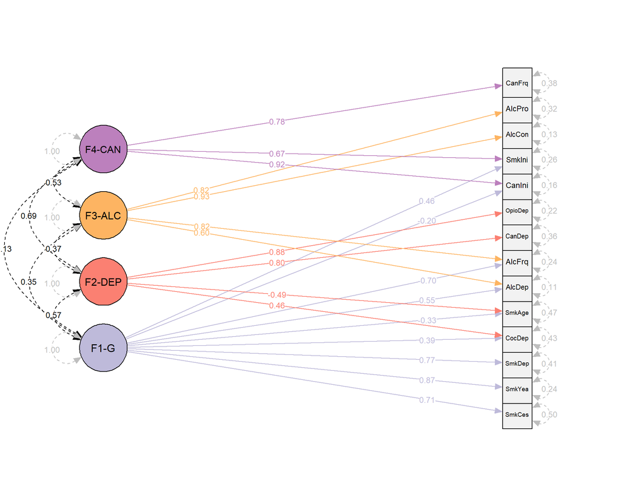

```r
semPaths(semPlotModel_GSEM(fit),
         layout="tree",
         curve = 2.5,
         whatLabels = "est",
         residuals = T,
         nodeLabels = nodelab,
         edge.color = edge.col,
         color = list(lat = c("#bebada", "#fb8072", "#fdb462", "#bc80bd"),
              man = "#f2f2f2"),
         rotation = 2
         , edge.label.position = c(rep(0.8, 9), rep(0.4, 4), rep(0.2, 4), rep(0.4, 3), rep(0.5, 30)),
         )
```

### 5 factors

EFA:

```r
load('data/mldsc_29May2023.14.TOT.RData')

Ssmooth <- as.matrix((nearPD(ldscOut$S, corr = FALSE))$mat)

EFA <-factanal(covmat = Ssmooth, factors = 5, rotation = 'promax')
```

```r
print(EFA, digits = 2, cutoff = .3, sort = TRUE)
```

```
##
## Call:
## factanal(factors = 5, covmat = Ssmooth, rotation = "promax")
##
## Uniquenesses:
##  SMKINI  SMKCES  PACKYE  SMKAGE  SMKDEP  ALCCON  ALCFRQ    ALCP  ALCDEP   CANEV
##    0.37    0.41    0.00    0.47    0.38    0.08    0.21    0.29    0.00    0.00
##  CANDEP   CANFL  COCDEP OPIODEP
##    0.35    0.21    0.17    0.00
##
## Loadings:
##         Factor1 Factor2 Factor3 Factor4 Factor5
## SMKCES   0.71
## PACKYE   1.18
## SMKDEP   0.78
## CANDEP           0.82
## COCDEP           0.55    0.46
## OPIODEP          1.14
## ALCDEP                   1.11
## CANEV                            0.98
## CANFL                            0.91
## ALCCON                                   0.86
## ALCFRQ                                   0.81
## ALCP                     0.33            0.67
## SMKINI                   0.34    0.43
## SMKAGE          -0.47   -0.37
##
##                Factor1 Factor2 Factor3 Factor4 Factor5
## SS loadings       2.68    2.58    2.04    2.04    1.91
## Proportion Var    0.19    0.18    0.15    0.15    0.14
## Cumulative Var    0.19    0.38    0.52    0.67    0.80
##
## Factor Correlations:
##         Factor1 Factor2 Factor3 Factor4 Factor5
## Factor1    1.00  -0.594   -0.73  -0.424   0.129
## Factor2   -0.59   1.000    0.74   0.067   0.043
## Factor3   -0.73   0.740    1.00   0.385  -0.244
## Factor4   -0.42   0.067    0.38   1.000  -0.422
## Factor5    0.13   0.043   -0.24  -0.422   1.000
##
## The degrees of freedom for the model is 31 and the fit was 28.358
```

CFA:

```r
load('data/mldsc_29May2023.14.TOT.RData')

CFA <- '
F1 =~ NA*SMKCES + PACKYE + SMKDEP
F2 =~ 1*COCDEP + CANDEP + OPIODEP + SMKAGE
F3 =~ NA*COCDEP + ALCDEP + ALCP + SMKINI +SMKAGE
F4 =~ NA*CANEV + CANFL + SMKINI
F5 =~ NA*ALCCON + ALCFRQ + ALCP

F1~~1*F1
F2~~1*F2
F3~~1*F3
F4~~1*F4
F5~~1*F5

a > .001
ALCCON ~~  a*ALCCON

'

#run the model
fit <- usermodel(ldscOut, estimation = "DWLS", model = CFA, CFIcalc = TRUE)
```

```r
fitlabel <- paste0("CFI = ", round(fit$modelfit$CFI,3), ", SRMR = ", round(fit$modelfit$SRMR,3))
kable(fitlabel)
```

| x |
| --- |
| CFI = 0.7, SRMR = 0.126 |

**Click to expand table with model parameters**

```r
kable(fit$results)
```

|  | lhs | op | rhs | Unstand_Est | Unstand_SE | STD_Genotype | STD_Genotype_SE | STD_All | p_value |
| --- | --- | --- | --- | --- | --- | --- | --- | --- | --- |
| 15 | F1 | =~ | SMKCES | 0.2068042 | 0.00941213464193239 | 0.7709308 | 0.0341026004317348 | 0.7709304 | 0.0000000 |
| 14 | F1 | =~ | PACKYE | 0.2753255 | 0.0124177076015544 | 0.9110754 | 0.0432076941245927 | 0.9110750 | 0.0000000 |
| 16 | F1 | =~ | SMKDEP | 0.2881022 | 0.0191546908231286 | 0.8181193 | 0.0520898778998261 | 0.8181152 | 0.0000000 |
| 21 | F2 | =~ | CANDEP | 0.2179418 | 0.0220714900107526 | 0.6674558 | 0.12922330878185 | 0.6674477 | 0.0000000 |
| 23 | F2 | =~ | OPIODEP | 0.3591128 | 0.0411206187386905 | 0.7373780 | 0.0822517907871577 | 0.7373683 | 0.0000000 |
| 24 | F2 | =~ | SMKAGE | -0.0407641 | 0.03207177828857 | 690.3656570 | 68282.025179624 | 690.3649591 | 0.2037185 |
| 30 | F3 | =~ | COCDEP | -0.5568240 | 0.0504029481226476 | -0.3197589 | 0.0602268804794639 | -0.3197597 | 0.0000000 |
| 28 | F3 | =~ | ALCDEP | 0.3382093 | 0.018091904623995 | 0.8405645 | 0.0443301865752005 | 0.8405628 | 0.0000000 |
| 29 | F3 | =~ | ALCP | 0.0295329 | 0.011225044884296 | 0.1261060 | 0.0420543997351367 | 0.1261060 | 0.0085138 |
| 32 | F3 | =~ | SMKINI | 0.2587611 | 0.0103495054029058 | 0.6927140 | 0.033128350890852 | 0.6927139 | 0.0000000 |
| 31 | F3 | =~ | SMKAGE | -0.1118333 | 0.0313613036036635 | -691.1838282 | 68282.026604518 | -691.1831294 | 0.0003625 |
| 35 | F4 | =~ | CANEV | 0.5630153 | 0.0365037488724444 | 1.0062837 | 0.0702906357207924 | 1.0062836 | 0.0000000 |
| 36 | F4 | =~ | CANFL | 0.1910415 | 0.0199025606523699 | 0.9050074 | 0.0939766344714555 | 0.9049490 | 0.0000000 |
| 37 | F4 | =~ | SMKINI | 0.1049103 | 0.0130606553051923 | 0.1879540 | 0.0489222517869808 | 0.1879540 | 0.0000000 |
| 39 | F5 | =~ | ALCCON | 0.2781264 | 0.01388255599069 | 1.0573467 | 0.0481470463987284 | 0.9995531 | 0.0000000 |
| 40 | F5 | =~ | ALCFRQ | 0.0987968 | 0.00701355551349435 | 0.3568151 | 0.0242188799264178 | 0.3568151 | 0.0000000 |
| 41 | F5 | =~ | ALCP | 0.1943128 | 0.0128958478019377 | 0.7957898 | 0.0524085848946978 | 0.7957899 | 0.0000000 |
| 1 | ALCCON | ~~ | ALCCON | 0.0010000 | 0.00625737542159177 | 0.0010000 | 0.0805835653753874 | 0.0008936 | 0.8730255 |
| 47 | SMKINI | ~~ | SMKINI | 0.0220665 | 0.00458921603804018 | 0.3528792 | 0.0354118737244184 | 0.3528791 | 0.0000015 |
| 45 | SMKCES | ~~ | SMKCES | 0.0294382 | 0.00391971281030944 | 0.4056667 | 0.0543614463708966 | 0.4056663 | 0.0000000 |
| 43 | PACKYE | ~~ | PACKYE | 0.0152394 | 0.00653654356579296 | 0.1699425 | 0.0715443839717722 | 0.1699424 | 0.0197312 |
| 44 | SMKAGE | ~~ | SMKAGE | 0.0256504 | 0.00213526203572001 | -42.5137155 | 4247.23730189404 | -42.5136295 | 0.0000000 |
| 46 | SMKDEP | ~~ | SMKDEP | 0.0408602 | 0.0168946897418255 | 0.3306910 | 0.136480862589651 | 0.3306876 | 0.0155836 |
| 3 | ALCFRQ | ~~ | ALCFRQ | 0.0730247 | 0.00305291024010109 | 0.8726830 | 0.0365345275686778 | 0.8726830 | 0.0000000 |
| 4 | ALCP | ~~ | ALCP | 0.0154480 | 0.00375924743747677 | 0.2580925 | 0.0633034811166504 | 0.2580926 | 0.0000397 |
| 2 | ALCDEP | ~~ | ALCDEP | 0.0303921 | 0.0252114155055196 | 0.2934553 | 0.171604487149541 | 0.2934542 | 0.2280144 |
| 6 | CANEV | ~~ | CANEV | 0.0124593 | 0.0390664843778586 | -0.0126066 | 0.135690484957314 | -0.0126066 | 0.7497825 |
| 5 | CANDEP | ~~ | CANDEP | 0.0421666 | 0.0286786891947369 | 0.5545271 | 0.317737598252667 | 0.5545136 | 0.1414776 |
| 7 | CANFL | ~~ | CANFL | 0.0084349 | 0.0157760424012625 | 0.1810907 | 0.350363838260847 | 0.1810674 | 0.5928796 |
| 8 | COCDEP | ~~ | COCDEP | -0.0341538 | 0.0946674387555685 | 0.5372390 | 0.168989117764627 | 0.5372414 | 0.7182660 |
| 42 | OPIODEP | ~~ | OPIODEP | 0.0707206 | 0.0701146799638736 | 0.4562999 | 0.346771608173042 | 0.4562879 | 0.3131467 |
| 10 | F1 | ~~ | F2 | 0.7027767 | 0.0419919736755263 | 0.7411435 | 0.039342006674443 | 0.7411435 | 0.0000000 |
| 11 | F1 | ~~ | F3 | 0.6769449 | 0.0335093001024403 | 0.7409609 | 0.0353212140821764 | 0.7409609 | 0.0000000 |
| 12 | F1 | ~~ | F4 | -0.0516508 | 0.0331988188680634 | -0.0555305 | 0.032484146685984 | -0.0555305 | 0.1197552 |
| 13 | F1 | ~~ | F5 | 0.1811442 | 0.0343930922328895 | 0.1734390 | 0.0338134810285134 | 0.1734390 | 0.0000001 |
| 18 | F2 | ~~ | F3 | 0.8784559 | 0.0482368446331999 | 0.9999551 | 0.00442531291724815 | 0.9999551 | 0.0000000 |
| 19 | F2 | ~~ | F4 | 0.3477685 | 0.0447439844723203 | 0.5070326 | 0.0643016807342778 | 0.5070326 | 0.0000000 |
| 20 | F2 | ~~ | F5 | 0.3186298 | 0.0387031562991456 | 0.4623648 | 0.0447262761724159 | 0.4623648 | 0.0000000 |
| 26 | F3 | ~~ | F4 | 0.3479254 | 0.0549749675424533 | 0.5066946 | 0.0660522776132504 | 0.5066946 | 0.0000000 |
| 27 | F3 | ~~ | F5 | 0.3290599 | 0.0364559508430307 | 0.4619807 | 0.038477940848349 | 0.4619807 | 0.0000000 |
| 34 | F4 | ~~ | F5 | 0.4379395 | 0.0366680820576923 | 0.4173233 | 0.0395633799466369 | 0.4173233 | 0.0000000 |
| 22 | F2 | =~ | COCDEP | 1.0000000 |  | 1.0000000 |  | 1.0000022 | NA |
| 9 | F1 | ~~ | F1 | 1.0000000 |  | 1.0000000 |  | 1.0000000 | NA |
| 17 | F2 | ~~ | F2 | 1.0000000 |  | 1.0000000 |  | 1.0000000 | NA |
| 25 | F3 | ~~ | F3 | 1.0000000 |  | 1.0000000 |  | 1.0000000 | NA |
| 33 | F4 | ~~ | F4 | 1.0000000 |  | 1.0000000 |  | 1.0000000 | NA |
| 38 | F5 | ~~ | F5 | 1.0000000 |  | 1.0000000 |  | 1.0000000 | NA |

#### Plot

```r
nodelab <- c( "SmkCes", "SmkYea","SmkDep",
              "CanDep", "OpioDep", "SmkAge", "CocDep",
              "AlcDep", "SmkIni", "AlcPro",
              "CanIni", "CanFrq",
              "AlcCon", "AlcFrq",
              "F1", "F2", "F3", "F4", "F5")

edge.col <- c(rep("#bebada",3),
              rep("#fb8072",3),
              rep("#fdb462",5),
              rep("#bc80bd",3),
              rep("lightgreen",3),
              rep("grey",14),
              rep("black", 10),
              "#fb8072",
              rep("grey", 5))


svg("results/semplot_5F_standard.svg", width = 10, height = 7)

plt <- semPaths(semPlotModel_GSEM(fit),
         layout="tree",
         curve = 2.5,
         whatLabels = "est",
         residuals = T,
         nodeLabels = nodelab,
         edge.color = edge.col,
         color = list(lat = c("#bebada", "#fb8072", "#fdb462", "#bc80bd", "lightgreen"),
              man = "#f2f2f2"),
         rotation = 2
         , edge.label.position = c(rep(0.3, 3), rep(0.5, 3), rep(0.7, 5), rep(0.5, 3), rep(0.3, 3), rep(0.5, 40)),
         )

dev.off()
```

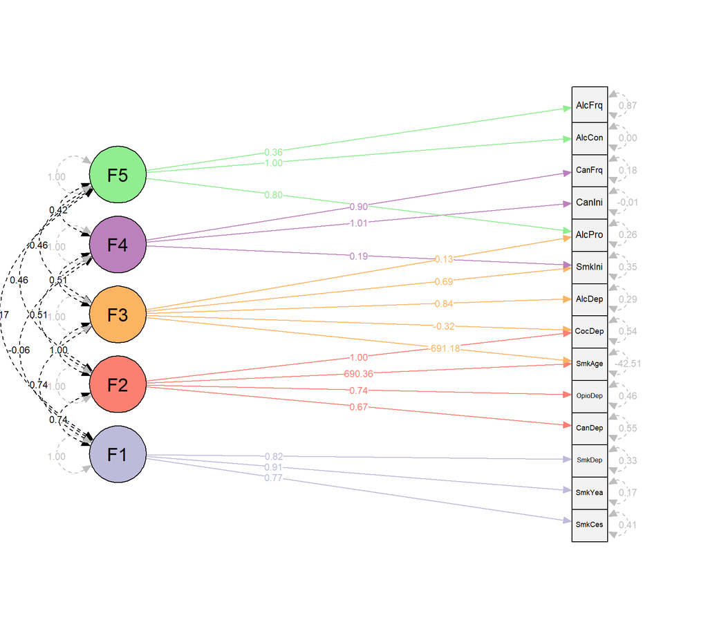

```r
semPaths(semPlotModel_GSEM(fit),
         layout="tree",
         curve = 2.5,
         whatLabels = "est",
         residuals = T,
         nodeLabels = nodelab,
         edge.color = edge.col,
         color = list(lat = c("#bebada", "#fb8072", "#fdb462", "#bc80bd", "lightgreen"),
              man = "#f2f2f2"),
         rotation = 2
         , edge.label.position = c(rep(0.3, 3), rep(0.5, 3), rep(0.7, 5), rep(0.5, 3), rep(0.3, 3), rep(0.5, 40)),
         )
```

### 6 factors

EFA:

```r
load('data/mldsc_29May2023.14.TOT.RData')

Ssmooth <- as.matrix((nearPD(ldscOut$S, corr = FALSE))$mat)

EFA <-factanal(covmat = Ssmooth, factors = 6, rotation = 'promax')
```

```r
print(EFA, digits = 2, cutoff = .3, sort = TRUE)
```

```
##
## Call:
## factanal(factors = 6, covmat = Ssmooth, rotation = "promax")
##
## Uniquenesses:
##  SMKINI  SMKCES  PACKYE  SMKAGE  SMKDEP  ALCCON  ALCFRQ    ALCP  ALCDEP   CANEV
##    0.28    0.58    0.51    0.00    0.62    0.27    0.27    0.19    0.00    0.00
##  CANDEP   CANFL  COCDEP OPIODEP
##    0.00    0.05    0.00    0.00
##
## Loadings:
##         Factor1 Factor2 Factor3 Factor4 Factor5 Factor6
## PACKYE   0.65
## ALCDEP   0.88    0.38
## COCDEP   1.10                                    0.52
## ALCCON   0.32    0.76
## ALCFRQ  -0.34    0.84
## ALCP             0.88
## CANEV                    0.91
## CANFL                    1.03
## SMKINI                   0.32   -0.54
## SMKAGE                           1.09
## CANDEP                                   1.02
## OPIODEP                                  0.40    0.67
## SMKCES   0.49
## SMKDEP   0.45
##
##                Factor1 Factor2 Factor3 Factor4 Factor5 Factor6
## SS loadings       3.18    2.27    2.08    1.61    1.40    0.85
## Proportion Var    0.23    0.16    0.15    0.11    0.10    0.06
## Cumulative Var    0.23    0.39    0.54    0.65    0.75    0.81
##
## Factor Correlations:
##         Factor1 Factor2 Factor3 Factor4 Factor5 Factor6
## Factor1   1.000    0.14  -0.679    0.67   0.025    0.13
## Factor2   0.139    1.00  -0.283    0.36  -0.338    0.49
## Factor3  -0.679   -0.28   1.000   -0.62   0.085   -0.12
## Factor4   0.672    0.36  -0.619    1.00  -0.144    0.19
## Factor5   0.025   -0.34   0.085   -0.14   1.000   -0.19
## Factor6   0.135    0.49  -0.117    0.19  -0.191    1.00
##
## The degrees of freedom for the model is 22 and the fit was 25.9761
```

CFA: Model fit is good, but factor 5 and 6 are similar, while there are no significant indicators for F6 and opioid dependence does not load significantly on F5, either. This solution is less parsimonious than a solution with fewer factors.

```r
load('data/mldsc_29May2023.14.TOT.RData')

CFA <- '
F1 =~ NA*PACKYE + ALCDEP + COCDEP + ALCCON + ALCFRQ + SMKCES + SMKDEP
F2 =~ NA*ALCDEP + ALCCON + ALCFRQ + ALCP
F3 =~ NA*CANEV + CANFL + SMKINI
F4 =~ NA*SMKINI + SMKAGE
F5 =~ NA*CANDEP + OPIODEP
F6 =~ NA*COCDEP + OPIODEP

F1~~1*F1
F2~~1*F2
F3~~1*F3
F4~~1*F4
F5~~1*F5
F6~~1*F6

a > .001
COCDEP ~~  a*COCDEP
'

#run the model
fit <- usermodel(ldscOut, estimation = "DWLS", model = CFA, CFIcalc = TRUE)
```

```r
fitlabel <- paste0("CFI = ", round(fit$modelfit$CFI,3), ", SRMR = ", round(fit$modelfit$SRMR,3))
kable(fitlabel)
```

| x |
| --- |
| CFI = 0.976, SRMR = 0.065 |

**Click to expand table with model parameters**

```r
kable(fit$results)
```

|  | lhs | op | rhs | Unstand_Est | Unstand_SE | STD_Genotype | STD_Genotype_SE | STD_All | p_value |
| --- | --- | --- | --- | --- | --- | --- | --- | --- | --- |
| 19 | F1 | =~ | PACKYE | 0.2676916 | 0.0103576419515745 | 0.8871752 | 0.0343270426381666 | 0.8871753 | 0.0000000 |
| 16 | F1 | =~ | ALCDEP | 0.2275080 | 0.0222898088820982 | 0.5979236 | 0.0585807766207527 | 0.5979236 | 0.0000000 |
| 18 | F1 | =~ | COCDEP | 0.3572640 | 0.496996851053696 | 0.6559973 | 0.917719137230974 | 0.6525887 | 0.4722360 |
| 15 | F1 | =~ | ALCCON | 0.0301075 | 0.00949876053797466 | 0.1144931 | 0.0361221174439088 | 0.1144931 | 0.0015264 |
| 17 | F1 | =~ | ALCFRQ | -0.1854296 | 0.0120944143198296 | -0.6444679 | 0.0420345750587949 | -0.6444679 | 0.0000000 |
| 20 | F1 | =~ | SMKCES | 0.1921474 | 0.00803887598834424 | 0.7150667 | 0.0299162634017219 | 0.7150668 | 0.0000000 |
| 21 | F1 | =~ | SMKDEP | 0.2727951 | 0.017866148417176 | 0.7751128 | 0.0507644801839301 | 0.7751128 | 0.0000000 |
| 28 | F2 | =~ | ALCDEP | 0.2225359 | 0.0223648708713692 | 0.5848578 | 0.0587781644657008 | 0.5848578 | 0.0000000 |
| 27 | F2 | =~ | ALCCON | 0.2306858 | 0.00821215924188816 | 0.8772583 | 0.0312294172382091 | 0.8772584 | 0.0000000 |
| 29 | F2 | =~ | ALCFRQ | 0.2316400 | 0.0109276896122496 | 0.8050737 | 0.0379796116120767 | 0.8050737 | 0.0000000 |
| 30 | F2 | =~ | ALCP | 0.2053015 | 0.00850241784680257 | 0.8535400 | 0.0353488424052388 | 0.8535399 | 0.0000000 |
| 35 | F3 | =~ | CANEV | 0.5119252 | 0.0284147860932681 | 0.8918972 | 0.0495053763844416 | 0.8918972 | 0.0000000 |
| 36 | F3 | =~ | CANFL | 0.1764907 | 0.0200560119125875 | 0.8326164 | 0.0946167690668221 | 0.8326163 | 0.0000000 |
| 37 | F3 | =~ | SMKINI | 0.1695337 | 0.0105529942251713 | 0.4916185 | 0.0306018796966117 | 0.4916185 | 0.0000000 |
| 42 | F4 | =~ | SMKINI | 0.2510533 | 0.0084546734953599 | 0.7280115 | 0.0245171266159134 | 0.7280116 | 0.0000000 |
| 41 | F4 | =~ | SMKAGE | -0.1768035 | 0.0065904464150627 | -0.8084420 | 0.0301350468011931 | -0.8084420 | 0.0000000 |
| 45 | F5 | =~ | CANDEP | 0.2598758 | 0.0571583422289179 | 0.8677868 | 0.190667461038733 | 0.8677881 | 0.0000055 |
| 46 | F5 | =~ | OPIODEP | 0.3633668 | 0.319441503165077 | 0.8140288 | 0.714802423041803 | 0.8140287 | 0.2553266 |
| 48 | F6 | =~ | COCDEP | 0.3968067 | 0.546955355026772 | 0.7288306 | 1.01023402420662 | 0.7250436 | 0.4681559 |
| 49 | F6 | =~ | OPIODEP | 0.1619249 | 0.310050461241975 | 0.3617761 | 0.694061953058199 | 0.3617761 | 0.6014940 |
| 8 | COCDEP | ~~ | COCDEP | 0.0010002 | 0.45089080672718 | 0.0010001 | 1.52781136673894 | 0.0009897 | 0.9982300 |
| 55 | SMKINI | ~~ | SMKINI | 0.0093196 | 0.00442562287367782 | 0.0783691 | 0.0372150861222272 | 0.0783691 | 0.0352202 |
| 53 | SMKCES | ~~ | SMKCES | 0.0352855 | 0.00338809471408426 | 0.4886795 | 0.0469223219064052 | 0.4886795 | 0.0000000 |
| 51 | PACKYE | ~~ | PACKYE | 0.0193848 | 0.00546593677526713 | 0.2129200 | 0.0600363960217349 | 0.2129200 | 0.0003904 |
| 52 | SMKAGE | ~~ | SMKAGE | 0.0165687 | 0.0022085100188777 | 0.3464217 | 0.0461759149407679 | 0.3464216 | 0.0000000 |
| 54 | SMKDEP | ~~ | SMKDEP | 0.0494459 | 0.0165742356716574 | 0.3992002 | 0.133810699701643 | 0.3992002 | 0.0028516 |
| 1 | ALCCON | ~~ | ALCCON | 0.0109716 | 0.00254052890413686 | 0.1586659 | 0.0367398093776774 | 0.1586660 | 0.0000157 |
| 3 | ALCFRQ | ~~ | ALCFRQ | 0.0198230 | 0.00340401571805578 | 0.2394504 | 0.0411184258268864 | 0.2394504 | 0.0000000 |
| 4 | ALCP | ~~ | ALCP | 0.0157057 | 0.0033974877653402 | 0.2714697 | 0.0587249887082741 | 0.2714696 | 0.0000038 |
| 2 | ALCDEP | ~~ | ALCDEP | 0.0139351 | 0.0260707805432681 | 0.0962522 | 0.180074751060786 | 0.0962522 | 0.5929875 |
| 6 | CANEV | ~~ | CANEV | 0.0673781 | 0.0259682353403534 | 0.2045194 | 0.0788240804296126 | 0.2045194 | 0.0094691 |
| 5 | CANDEP | ~~ | CANDEP | 0.0221298 | 0.0419625979508965 | 0.2469431 | 0.467707700521989 | 0.2469438 | 0.5979375 |
| 7 | CANFL | ~~ | CANFL | 0.0137828 | 0.015655013930256 | 0.3067501 | 0.348417317006699 | 0.3067500 | 0.3786371 |
| 50 | OPIODEP | ~~ | OPIODEP | 0.0065413 | 0.0933255316805935 | 0.0328499 | 0.467583994591659 | 0.0328499 | 0.9441215 |
| 10 | F1 | ~~ | F2 | 0.2919324 | 0.0427492802883659 | 0.2919306 | 0.042749426492897 | 0.2919306 | 0.0000000 |
| 11 | F1 | ~~ | F3 | -0.0176454 | 0.0367636733665367 | -0.0176465 | 0.0367637185158242 | -0.0176465 | 0.6312506 |
| 12 | F1 | ~~ | F4 | 0.7154365 | 0.0232635736807385 | 0.7154392 | 0.0232636238785388 | 0.7154392 | 0.0000000 |
| 13 | F1 | ~~ | F5 | 0.5785146 | 0.164930668480769 | 0.5785966 | 0.164846435642842 | 0.5785966 | 0.0004521 |
| 14 | F1 | ~~ | F6 | 0.0517405 | 1.31023947053975 | 0.0501423 | 1.31543366742106 | 0.0501423 | 0.9685003 |
| 23 | F2 | ~~ | F3 | 0.5177153 | 0.0294409814561367 | 0.5177154 | 0.0294410215305333 | 0.5177154 | 0.0000000 |
| 24 | F2 | ~~ | F4 | 0.2784575 | 0.0372981557438669 | 0.2784583 | 0.0372982165787628 | 0.2784583 | 0.0000000 |
| 25 | F2 | ~~ | F5 | 0.3770315 | 0.122280099231397 | 0.3771043 | 0.122245454769795 | 0.3771043 | 0.0020469 |
| 26 | F2 | ~~ | F6 | 0.2202560 | 0.646028810969768 | 0.2194015 | 0.648666435522971 | 0.2194015 | 0.7331500 |
| 32 | F3 | ~~ | F4 | 0.2094712 | 0.0509298845869784 | 0.2094714 | 0.0509298500837399 | 0.2094714 | 0.0000391 |
| 33 | F3 | ~~ | F5 | 0.4244770 | 0.140008458579734 | 0.4245309 | 0.139959558847016 | 0.4245309 | 0.0024310 |
| 34 | F3 | ~~ | F6 | 0.3485237 | 0.471778941336359 | 0.3478724 | 0.473394048307024 | 0.3478724 | 0.4600627 |
| 39 | F4 | ~~ | F5 | 0.6385802 | 0.143295321498325 | 0.6386194 | 0.143147312806466 | 0.6386194 | 0.0000083 |
| 40 | F4 | ~~ | F6 | 0.1032738 | 1.03597561052872 | 0.1019406 | 1.03990638485161 | 0.1019406 | 0.9205925 |
| 44 | F5 | ~~ | F6 | 0.2964592 | 1.16530396419247 | 0.2947840 | 1.1692076519751 | 0.2947840 | 0.7991827 |
| 9 | F1 | ~~ | F1 | 1.0000000 |  | 1.0000000 |  | 1.0000000 | NA |
| 22 | F2 | ~~ | F2 | 1.0000000 |  | 1.0000000 |  | 1.0000000 | NA |
| 31 | F3 | ~~ | F3 | 1.0000000 |  | 1.0000000 |  | 1.0000000 | NA |
| 38 | F4 | ~~ | F4 | 1.0000000 |  | 1.0000000 |  | 1.0000000 | NA |
| 43 | F5 | ~~ | F5 | 1.0000000 |  | 1.0000000 |  | 1.0000000 | NA |
| 47 | F6 | ~~ | F6 | 1.0000000 |  | 1.0000000 |  | 1.0000000 | NA |

#### Plot

```r
nodelab <- c("SmkYea", "SmkCes", "SmkDep", "AlcDep", "AlcCon", "AlcFrq",
             "AlcPro",  "CocDep",
             "CanIni", "CanFrq", "SmkIni",
             "SmkAge",
             "CanDep",
             "OpioDep",
             "F1", "F2", "F3", "F4", "F5", "F6")

edge.col <- c(rep("#bebada",7),
              rep("#fb8072",4),
              rep("#fdb462",3),
              rep("#bc80bd",2),
              rep("lightgreen",2),
              rep("skyblue3", 2),
              rep("grey",14),
              rep("black", 15),
              rep("grey", 6))


svg("results/semplot_6F_standard.svg", width = 10, height = 8)


plt <- semPaths(semPlotModel_GSEM(fit),
         layout="tree",
         curve = 2.5,
         whatLabels = "est",
         residuals = T,
         nodeLabels = nodelab,
         edge.color = edge.col,
         color = list(lat = c("#bebada", "#fb8072", "#fdb462", "#bc80bd", "lightgreen", "skyblue3"),
              man = "#f2f2f2"),
         rotation = 2
         , edge.label.position = c(rep(0.8, 7), rep(0.4, 4), rep(0.6, 3), rep(0.4, 2), rep(0.4, 2), rep(0.2, 2), rep(0.5, 50)),
         )

dev.off()
```

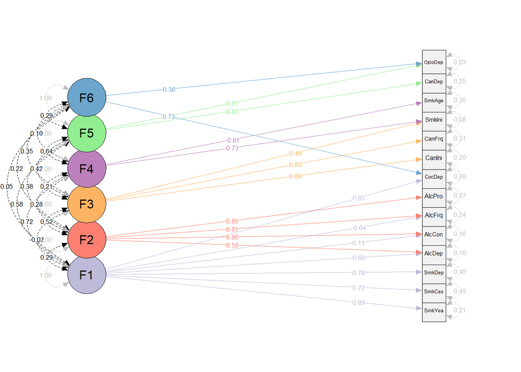

```r
plt <- semPaths(semPlotModel_GSEM(fit),
         layout="tree",
         curve = 2.5,
         whatLabels = "est",
         residuals = T,
         nodeLabels = nodelab,
         edge.color = edge.col,
         color = list(lat = c("#bebada", "#fb8072", "#fdb462", "#bc80bd", "lightgreen", "skyblue3"),
              man = "#f2f2f2"),
         rotation = 2
         , edge.label.position = c(rep(0.8, 7), rep(0.4, 4), rep(0.6, 3), rep(0.4, 2), rep(0.4, 2), rep(0.2, 2), rep(0.5, 50)),
         )
```